***Created by Antoine Courbi and Cesar Delaygues***

# ***Canny filter***

- Noise Reduction (Gaussian Blur)
- Gradient Calculation (Sobel Kernel)
- Non-maximum Suppression (Thinning / keeping just the edges )
- Double Threshold (filtering: delete edge under low threshold / identify strong edges above high threshold / identify weak edges between the low and high threshold)
- Edge Tracking by Hysteresis (keep weak edges only if they are connected to a strong one)

```python
!pip install scikit-image
```

[output not shown]

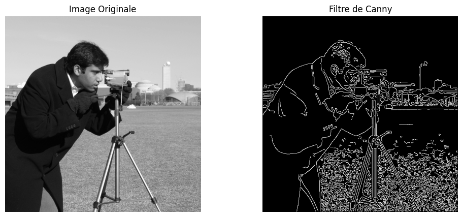

```python
import matplotlib.pyplot as plt
from skimage import data, feature

# Charger une image de test depuis scikit-image
image = data.camera()

# Appliquer le filtre de Canny
edges = feature.canny(image)

# Afficher l'image originale et l'image avec le filtre de Canny
fig, (ax1, ax2) = plt.subplots(1, 2, figsize=(12, 5))

ax1.imshow(image, cmap='gray')
ax1.set_title('Image Originale')
ax1.axis('off')

ax2.imshow(edges, cmap='gray')
ax2.set_title('Filtre de Canny')
ax2.axis('off')

plt.show()
```

```python
!pip install opencv-python
```

[output not shown]

[figure not shown]

```python
import cv2
import numpy as np
import matplotlib.pyplot as plt

# Définir différentes tailles de noyau et valeurs sigma
kernel_sizes = [(5, 5), (11, 11), (17, 17)]
sigmas = [0.5, 3, 9]

# Appliquer le flou gaussien avec différentes tailles de noyau et valeurs sigma
fig, axes = plt.subplots(len(kernel_sizes), len(sigmas), figsize=(15, 10))
for i, kernel_size in enumerate(kernel_sizes):
    for j, sigma in enumerate(sigmas):
        blurred_image = cv2.GaussianBlur(image, kernel_size, sigma)
        ax = axes[i, j]
        ax.imshow(blurred_image, cmap='gray')
        ax.set_title(f"Kernel Size: {kernel_size}, Sigma: {sigma}")
        ax.axis('off')

plt.tight_layout()
plt.show()
```

```python
def custom_convolution(input_image, kernel):
    kernel_height, kernel_width = kernel.shape
    image_height, image_width = input_image.shape

    # Create an empty output array
    output = np.zeros((image_height, image_width))

    # Pad the input image
    pad_height = kernel_height // 2
    pad_width = kernel_width // 2
    padded_image = np.pad(input_image, ((pad_height, pad_height), (pad_width, pad_width)), mode='constant', constant_values=0)

    # Perform the convolution using two for loops
    for i in range(image_height):
        for j in range(image_width):
            # Extract the part of the image where we will apply the kernel
            region = padded_image[i:i+kernel_height, j:j+kernel_width]
            # Perform the convolution (element-wise multiplication and sum)
            output[i, j] = np.sum(region * kernel)

            # Clipping the values to be in [0, 255] interval if the image is uint8 type
            if output[i, j] < 0:
                output[i, j] = 0
            elif output[i, j] > 255:
                output[i, j] = 255

    return output.astype(np.uint8)
```

```python
kernel = np.array([[ 0, -1,  0],
                   [-1,  5, -1],
                   [ 0, -1,  0]])
output_image = custom_convolution(image, kernel)
output_image
```

```
array([[255, 255, 255, ..., 255, 255, 255],
       [255, 197, 197, ..., 191, 190, 255],
       [255, 198, 198, ..., 190, 190, 255],
       ...,
       [ 50,  22,  34, ...,  86,  34, 255],
       [ 50,  24,  27, ..., 220, 105, 255],
       [ 75,  48,  59, ..., 255, 255, 255]], dtype=uint8)
```

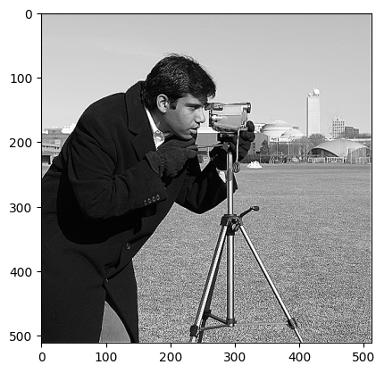

```python
plt.imshow(output_image, cmap='gray')
```

[figure not shown]

```python
kernel = np.array([[-2, -1, 0],
                   [-1,  1, 1],
                   [ 0,  1, 2]])
output_image = custom_convolution(image, kernel)
plt.imshow(output_image, cmap='gray')
```

# ***Palet Breton***

***Import necessary libraries***

```python
import numpy as np
import matplotlib.pyplot as plt
import skimage

from skimage import data, color
from skimage.transform import hough_circle, hough_circle_peaks
from skimage.feature import canny
from skimage.draw import circle_perimeter
from skimage.util import img_as_ubyte

from skimage.filters import gaussian
```

Looking at what has already been made on **internet**, we ended up finding a good **example** in the `documentation` [here](https://scikit-image.org/docs/stable/auto_examples/edges/plot_circular_elliptical_hough_transform.html#sphx-glr-auto-examples-edges-plot-circular-elliptical-hough-transform-py) where we found that :

```
# Detect two radii
hough_radii = np.arange(20, 35, 2)
hough_res = hough_circle(edges, hough_radii)

# Select the most prominent 3 circles
accums, cx, cy, radii = hough_circle_peaks(hough_res, hough_radii,
                                           total_num_peaks=3)
```

Based on what we have found, we want to :

- Load and modify the image
- Apply a Canny filter
- Apply a Hough transform
- Draw the circles/Retrieve the coordinates of the cochonet

### 1 - Load and modify the image

```python
# load and detect edges
file = "palet_breton_input_images\palet_breton_input_images\photo3.jpeg"
image = skimage.io.imread(file)
```

Now we want to remove the last digit of the image as its constant 255 and can't be read by the Canny filter.  
We want to convert the image to hsv color space before applying greyscale as it is easier to work with and had best results.  
We also want to keep only the bluescale as its in that channel that we can best see the palets.  
And finally we want to apply blur using a gaussian filter to remove noise.

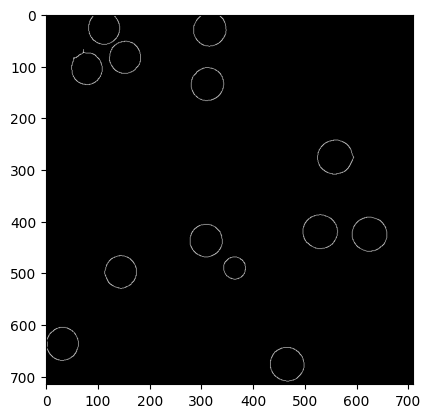

```python
# remove last dimension
image = image[:,:,0:3]

# convert to hsv color space
image = skimage.color.rgb2hsv(image)

# retrieve the different channels
red_channel = image[:, :, 0]
green_channel = image[:, :, 1]
blue_channel = image[:, :, 2]

# convet to grey scale
image = skimage.color.rgb2gray(image)

# we want to blur the image to remove noise of the background
image = gaussian(blue_channel, sigma=1)

# plot the image with imshow
plt.imshow(image, cmap=plt.cm.gray)

image = img_as_ubyte(image)
edges = canny(image, sigma=3, low_threshold=40, high_threshold=90)
plt.imshow(edges, cmap=plt.cm.gray)
```

### 2 - Look for the palets

The image above shows the edge detection after applying the Canny filter.  
As we can see it performs really well and we can see the palets clearly, the noisy background is removed and the palets are well defined.

The next step is to apply the Hough transform to detect the circles.  
From the results, we will be able to get the coordinates of the minimum enclosing circle of the palets, which is the cochonet.

```
The cochonet is at (364, 490) with a radius of 21 pixels
```

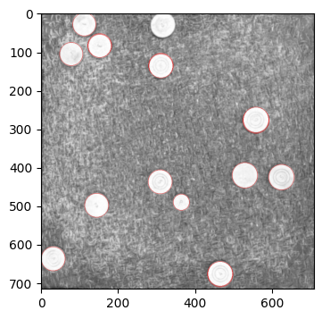

```python
# Detect two radii
hough_radii = np.arange(10, 50, 1)
hough_res = hough_circle(edges, hough_radii)

# Select the most prominent circles
accums, cx, cy, radii = hough_circle_peaks(hough_res, hough_radii,
                                           total_num_peaks=16)


# look for all the smallest radius
min_radius = np.min(radii)
# look for closest circle to the smallest radius
index = np.argmin(radii)
# get the center of the circle
center = (cx[index], cy[index])
print(f"The cochonet is at {center} with a radius of {radii[index]} pixels")

# Draw them
fig, ax = plt.subplots(ncols=1, nrows=1, figsize=(10, 4))
image = color.gray2rgb(image)

for center_y, center_x, radius in zip(cy, cx, radii):
    #print("Thats a palet breton !")
    circy, circx = circle_perimeter(center_y, center_x, radius,
                                    shape=image.shape)
    image[circy, circx] = (220, 20, 20)

# show the image
ax.imshow(image, cmap=plt.cm.gray)
plt.show()
```

Ok it worked well !  
We found the coordinates for the photo3 at : (364, 490).